# Cross Validation

Irving, Chuy

2025-03-07

## Validación cruzada

A continuación se entrena un modelo con validación cruzada para después comparar su rendimiento con el arbol de decisión.

## Validación cruzada para clasificacion

```
## CART
##
## 1021 samples
##   80 predictor
##    3 classes: 'barata', 'estandar', 'cara'
##
## No pre-processing
## Resampling: Cross-Validated (5 fold)
## Summary of sample sizes: 818, 817, 816, 816, 817
## Resampling results across tuning parameters:
##
##   cp          Accuracy   Kappa
##   0.04444444  0.6875580  0.5313929
##   0.12740741  0.6288106  0.4443884
##   0.39851852  0.4945131  0.2400887
##
## Accuracy was used to select the optimal model using the largest value.
## The final value used for the model was cp = 0.04444444.
```

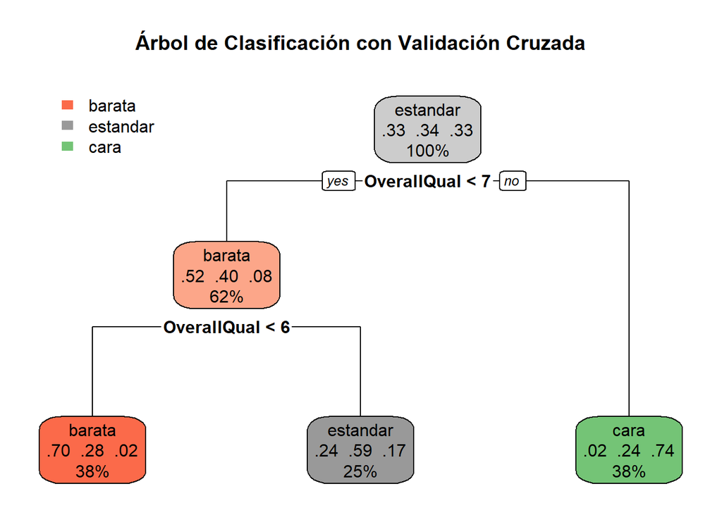

```
##           cp  Accuracy     Kappa  AccuracySD    KappaSD
## 1 0.04444444 0.6875580 0.5313929 0.009473407 0.01446576
## 2 0.12740741 0.6288106 0.4443884 0.027889301 0.04084461
## 3 0.39851852 0.4945131 0.2400887 0.142661069 0.21917743
```

## Probando con diferentes profundidades

```
## [1] "Mostrando el árbol: modelo1 - Profundidad: 4"
```

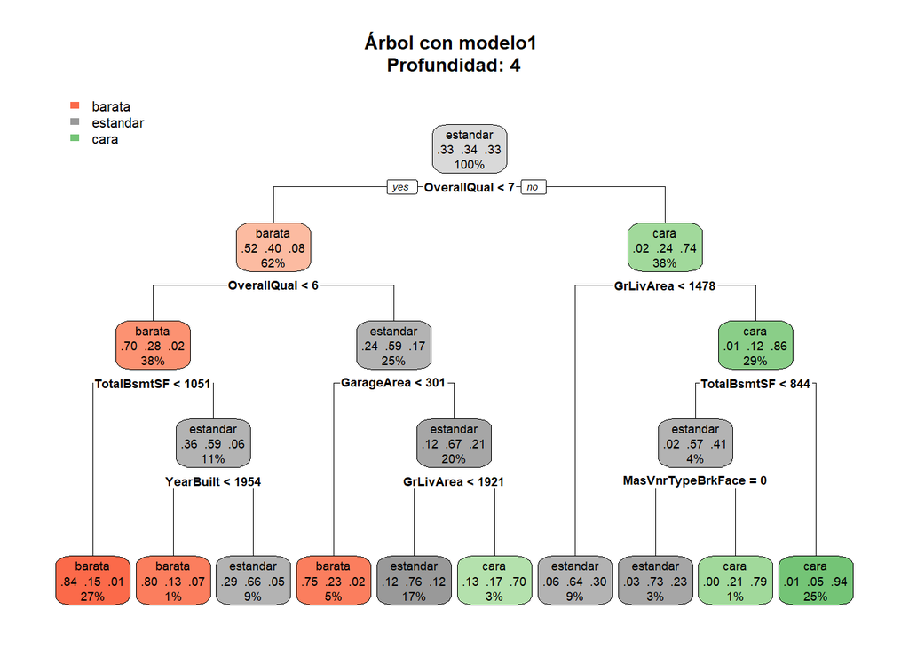

```
## [1] "Mostrando el árbol: modelo2 - Profundidad: 6"
```

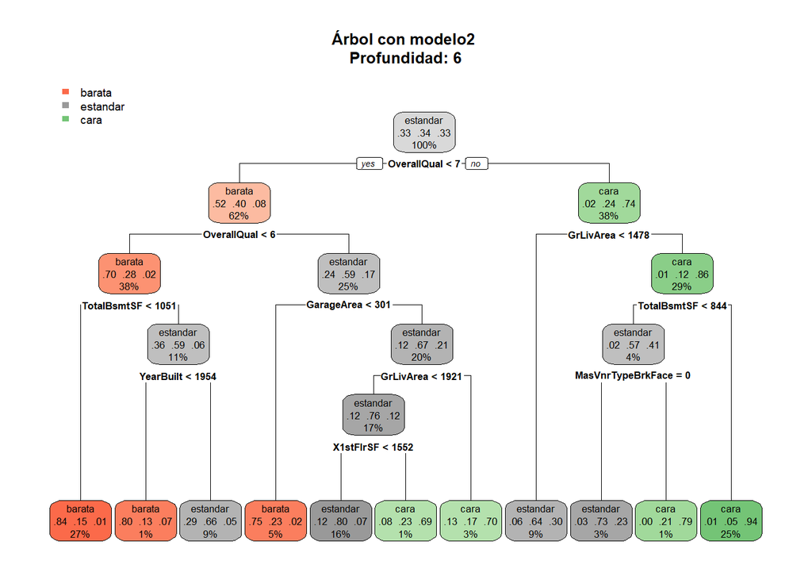

```
## [1] "Mostrando el árbol: modelo3 - Profundidad: 8"
```

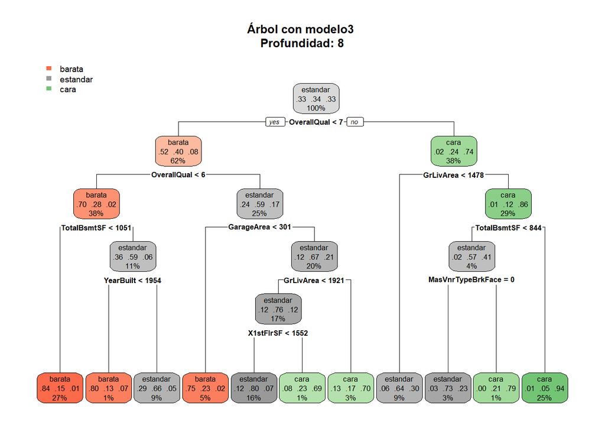

```r
# Definir configuraciones de profundidad
depth_settings <- list(
  modelo1 = list(maxdepth = 4),
  modelo2 = list(maxdepth = 6),
  modelo3 = list(maxdepth = 8)
)

# Crear lista para almacenar los modelos
resultados <- list()

# Entrenar los modelos con diferentes profundidades
for (nombre in names(depth_settings)) {
  set.seed(123)
  modelo <- train(
    consumoCat ~ .,
    data = train_data,
    method = "rpart",
    trControl = trainControl(method = "cv", number = 5),
    tuneLength = 10,  # Ajusta automáticamente cp probando 10 valores diferentes
    control = rpart.control(maxdepth = depth_settings[[nombre]]$maxdepth)
  )
  resultados[[nombre]] <- modelo
}

accuracy_results <- data.frame(
  Modelo = character(),
  Profundidad = numeric(),
  Accuracy = numeric(),
  stringsAsFactors = FALSE
)

for (nombre in names(resultados)) {
  profundidad <- depth_settings[[nombre]]$maxdepth
  accuracy <- max(resultados[[nombre]]$results$Accuracy)

  accuracy_results <- rbind(accuracy_results, data.frame(
    Modelo = nombre,
    Profundidad = profundidad,
    Accuracy = accuracy
  ))

  print(paste("Mostrando el árbol:", nombre, "- Profundidad:", profundidad))

  rpart.plot(resultados[[nombre]]$finalModel, main = paste("Árbol con", nombre, "\nProfundidad:", profundidad))
}
```

```r
print(accuracy_results)
```

```
##    Modelo Profundidad  Accuracy
## 1 modelo1           4 0.7482758
## 2 modelo2           6 0.7629723
## 3 modelo3           8 0.7629723
```

Al realizar las prueba de validación cruzada para distintos niveles de profundida en el árbol, observamos que entre la profundiad de 6 y 8 no encontramos diferencia alguna, lo que nos dice que 6 es el máximo de profundida significante. El valor del `acurracy` es de *0.7630*, el cual ha sido hasta ahora el nivel más alto que se ha obtenido.

#Prueba de árbol de decisión pero ahora con random forest

```r
str(train_data)
```

```
## tibble [1,021 × 81] (S3: tbl_df/tbl/data.frame)
##  $ Id           : num [1:1021] 415 463 179 526 195 ...
##  $ MSSubClass   : num [1:1021] 60 20 20 20 20 60 60 60 20 20 ...
##  $ MSZoning     : chr [1:1021] "RL" "RL" "RL" "FV" ...
##  $ LotFrontage  : num [1:1021] 59 60 63 62 60 75 70 107 62 89 ...
##  $ LotArea      : num [1:1021] 11228 8281 17423 7500 7180 ...
##  $ Street       : chr [1:1021] "Pave" "Pave" "Pave" "Pave" ...
##  $ Alley        : chr [1:1021] "Grvl" "Grvl" "Grvl" "Pave" ...
##  $ LotShape     : chr [1:1021] "IR2" "IR1" "IR1" "Reg" ...
##  $ LandContour  : chr [1:1021] "Lvl" "Lvl" "Lvl" "Lvl" ...
##  $ Utilities    : chr [1:1021] "AllPub" "AllPub" "AllPub" "AllPub" ...
##  $ LotConfig    : chr [1:1021] "CulDSac" "Inside" "CulDSac" "Inside" ...
##  $ LandSlope    : chr [1:1021] "Gtl" "Gtl" "Gtl" "Gtl" ...
##  $ Neighborhood : chr [1:1021] "SawyerW" "Sawyer" "StoneBr" "Somerst" ...
##  $ Condition1   : chr [1:1021] "Norm" "Norm" "Norm" "Norm" ...
```

[output cut: 67 more lines]

```r
train_data <- train_data %>% select(-c("Id"))

control <- trainControl(method = "cv", number = 5)

# Entrenar el modelo de Random Forest
set.seed(123)
modelo_rf <- train(
  consumoCat ~ .,  # Formula: predecir consumoCat usando todas las demás columnas
  data = train_data,
  method = "rf",  # Random Forest
  trControl = control,
  metric = "Accuracy",
  tuneLength = 5,
  ntree = 500
)

modelo_rf
```

```
## Random Forest
##
## 1021 samples
##   79 predictor
##    3 classes: 'barata', 'estandar', 'cara'
##
## No pre-processing
## Resampling: Cross-Validated (5 fold)
## Summary of sample sizes: 818, 817, 816, 816, 817
## Resampling results across tuning parameters:
##
##   mtry  Accuracy   Kappa
##     2   0.7610259  0.6421096
##    61   0.8393624  0.7590086
##   121   0.8364308  0.7546191
##   181   0.8305676  0.7458353
##   241   0.8325235  0.7487482
##
## Accuracy was used to select the optimal model using the largest value.
## The final value used for the model was mtry = 61.
```

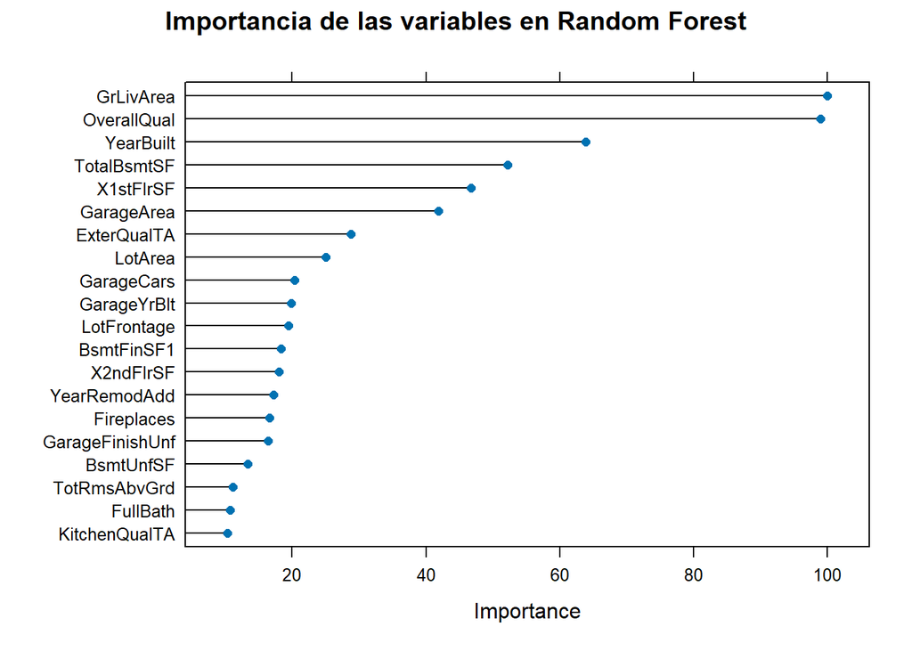

```r
# Ver la importancia de las variables
var_importance <- varImp(modelo_rf)
plot(var_importance, main = "Importancia de las variables en Random Forest", top = 20)
```

```r
# Comparar con el accuracy del árbol de decisión
print(paste("Accuracy del árbol de decisión:", max(resultados$modelo3$results$Accuracy)))
```

```
## [1] "Accuracy del árbol de decisión: 0.762972344530748"
```

```r
print(paste("Accuracy de Random Forest:", max(modelo_rf$results$Accuracy)))
```

```
## [1] "Accuracy de Random Forest: 0.839362385829016"
```

Como se puede observar al final este fue el mejor resultado de todos los modelos que fueron entrenados, superando incluso al algoritmo de regresión lineal y las clasificaciones realizadas anteriormente. Es incluso mejor que el random forest de regresion. Logrando un Accuracy de 83%, este algoritmo es mucho más pesado que los demás debido a que aparte de hacer tuning para la mejora de hiperparámetros, se están realizando una gran cantidad de árboles para poder determinar variables más importantes. Al tener muchos arboles (500 en este caso de prueba), lo que hace esto es haer muchas predicciones dentro del entrenamiento con los distintos arboles. Los árboles tienen bastante variabilidad, ya que el muestro involucra distintos procesos aleatorios, lo cuál nos garantiza una mayor generalización y menos overfitting (el cuál fue el problema que tuvimos con la regresión lineal). Además, en este caso la clasificación ayuda bastante a que el modelo pueda predecir sobre una variable discreta (categoría de la casa) en un lugar de una variable continua (el precio). Ya que se tienen definidos rangos es que el módelo busca la mayor coincidencia entre las predicciones de los distintos árboles. Esta discretización ayuda mucho a mejroar el desempeño y nos permitió un realizar un modelo con alto accuracy tomando en cuenta las variables más relevantes. Como se puede ver en la gráfica, las variables más importante coinciden con las que se analizaron tanto la regresión lineal como en el arbol de clasificación. Por lo que podemos concluir que el modelo entrenado es bastante preciso y generalizado.Otro indicador además de l accuracy es el kappa. Este resultó ser mucho mayor a 0.50 (0.75 al final), lo cuál indica que el módelo no solo predice aleatoriamente y que de hecho es mejor que una clasificación aleatoria.